# Rmarkdown introduction

2024-02-12

## Markdown

- Lightweight markup language for creating formatted text using a plain-text editor
- Created by **John Gruber** and **Aaron Swartz** in **2004**
- **Aim:** Ease plain text conversion into rich text format, without any heavy codes

## R Markdown

- Package developped by **Yihui Xie** to integrated Markdown langage into R (around **2012** - 2014)
- **Aim:** Facilitate reproducible research, allowing codes sharing with textual documentation on different form *(LaTeX, HTML, Markdown, etc.)* and for dynamic report generation with R.
- Yihui Xie: Author of **Knitr**, **blogdown**, **bookdown** etc.

## R markdown - Fonctionalities

- R Markdown family of packages enables creating beautiful data science products like:
  - books, blogs, websites, and presentations etc.
- Aim: help you publish polished websites for sharing your work. E.g.:
  - Present analyses or visualizations with R code ([Ex. My tutorial](https://rpubs.com/antoine-kossi/sir-analysis-with-r)),
  - Slides (like this one you are seing),
  - R package ([My package](https://package-metaan-rep.github.io/Metaan/)),
  - Personal-professional websites, etc.

## Overview: Start using Rmarkdown

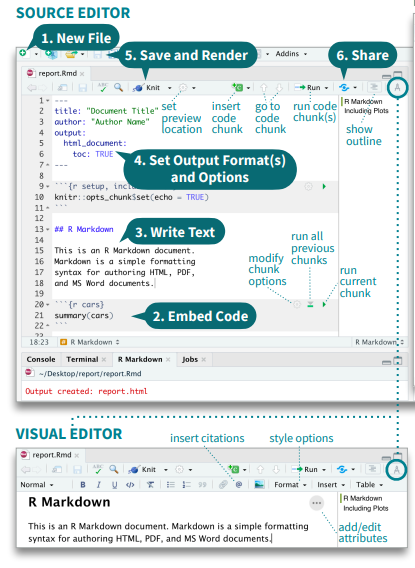

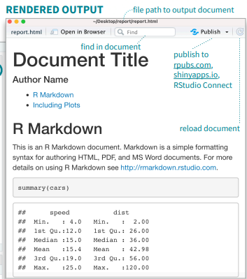

## The magic behind

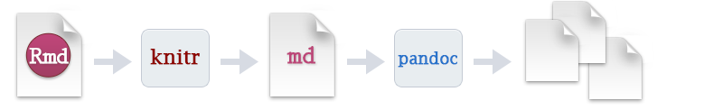

When you run render, R Markdown feeds the .Rmd file to knitr, which executes all of the code chunks and creates a new markdown (.md) document which includes the code and its output.

The markdown file generated by knitr is then processed by pandoc which is responsible for creating the finished format.

## Codes chunks

[figure not shown]

## Inline coding

*NB: Chunk options for personnalised code output*

```r
# This is an example
a <- c(1,2,3,4)
cat("The output of a =", a)
```

```
## The output of a = 1 2 3 4
```

## Tables - Figures

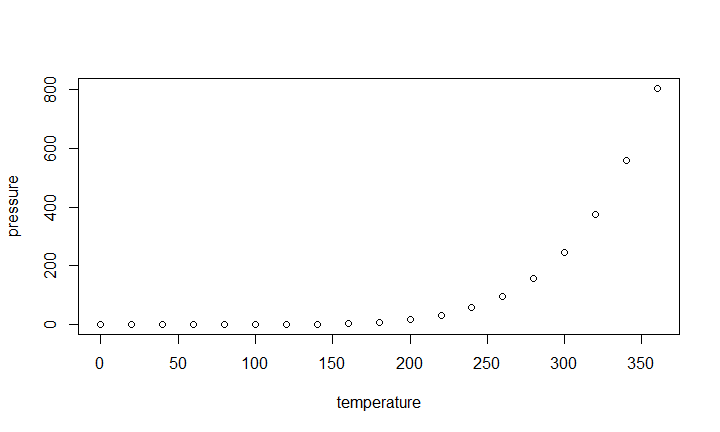

```r
plot(pressure)
```

## Tables - Figures

Example of embended table

| age_group | Number_events | Pers_years |
| --- | --- | --- |
| 35-39 | 0 | 480 |
| 40-44 | 1 | 587 |
| 45-49 | 3 | 680 |
| 50-54 | 5 | 541 |
| 55-59 | 8 | 479 |
| 60-64 | 8 | 356 |
| 65-69 | 4 | 157 |
| 70-74 | 1 | 36 |

## Interactive Documents

R Markdown documents are a perfect platform for interactive content. To make your documents interactive, add:

- Interactive JavaScript visualizations based on htmlwidgets, or
- Reactive components made with Shiny (**upcoming coding clubs**)

[Interactive table](https://rpubs.com/antoine-kossi/sir-analysis-with-r)

Scientific articles

## Additional resources

[The reference guide](https://www.rstudio.com/wp-content/uploads/2015/03/rmarkdown-reference.pdf)

[The Rmarkdown cheatsheet](https://rmarkdown.rstudio.com/lesson-15.html)

### **Let’s put this into practice**

- If you don’t have R and Rstudio installed, you can create a free account on [R Studio Cloud](https://posit.cloud/) and start using R.